# Research-In-Progress

Anish Sanjay Shah, MD/MS  
Cardiology Fellow  
University of Illinois at Chicago

# July 11, 2022

| Projects | Status | Product | Effort |
| --- | --- | --- | --- |
| MS and CV Mortality | Working on tables and figures | NA | 20% |
| AF Registry | Revise data dictionary | NA | 20% |
| F32/T32/K23 | Considering isoproterenol washout | NA | 20% |
| UIC Clinic | Weekly clinic with Mary | NA | 10% |
| EP Lab | TBD | NA | 10% |
| PERT | TBD | NA | 5% |
| Studying | TBD | NA | 5% |
| Endocarditis and Pixel Density | TBD | NA | 5% |
| Modeling Software | Modeling in epidemiology | NA | 5% |
| Signal Processing | TBD | NA | 5% |
| Endocarditis and Arrhythmias | Outlining | NA | 2% |
| HRV and CAD | Continuous ECG recordings at Emory in CAD patients | NA | 1% |

# July 18, 2022

| Projects | Status | Product | Effort |
| --- | --- | --- | --- |
| MS and CV Mortality | Team = Amit Shah (*Emory*) Draft to co-authors | NA | 20% |
| AF Registry | Data validation started, revisit variables | NA | 20% |
| F32/T32/K23 | Reviewing autonomic literature at translational/basic science level | NA | 20% |
| UIC Clinic | Weekly clinic with Mary | NA | 10% |
| EP Lab | Considering 1 to 2 cases this week | NA | 10% |
| PERT | Education and research IRB | NA | 5% |
| Studying | General cardiology/echo boards in **Fall 2023 | NA | 5% |
| Endocarditis and Pixel Density | Processing images pending | NA | 5% |
| Modeling Software | Writing code for forest plots in {R} | NA | 5% |
| Signal Processing | Practicing data extraction at UIC, but still need JBVA access {MATLAB} | NA | 5% |
| Endocarditis and Arrhythmias | Outlining with student | NA | 2% |
| HRV and CAD | Emory Biobank continually recruiting | NA | 1% |

## AF Registry

The AF registry is described [here](https://asshah4.github.io/afib). Current issues:

1. Data quality - consistency between reviewers
2. Missingness - decisions on acceptable thresholds
3. Variable selection - echo findings, EP studies, medications, labs, symptoms
4. Management - REDCap, shared excel sheet
5. Adjudication/review - outcomes, clinical follow-up length

# July 25, 2022

| Projects | Status | Product | Effort |
| --- | --- | --- | --- |
| MS and CV Mortality | Team = Amit Shah (*Emory*) Final figures of mortality by subgroups **7/25** Revise discussion on vagal withdrawal **6/26** | NA | 20% |
| F32/T32/K23 | Aim 1 = Human vagolysis and SCD **Aim 2 = Murine model of vagal withdrawal and arrhythmia** Active research into model development **daily** | NA | 20% |
| AF Registry | Decide on retrospective/prospective cohort definitions **TBD** | NA | 10% |
| UIC Clinic | Weekly clinic with Dr. Ziccardi | NA | 10% |
| EP Lab | Discuss with Adam which cases to cover this week | NA | 10% |
| PERT | Submit IRB for education and clinical data **7/28** | NA | 10% |
| Endocarditis and Pixel Density | Team = Lee Frazin, Satish Mishra, David Polman Revise still images to create standard for processing and SOP **7/30** | NA | 10% |
| Modeling Software | Forest plots by subgroups in {R}, **drafted** | NA | 5% |
| Signal Processing | Convert CARTO data into OpenEP **7/31** | NA | 5% |
| Studying | General cardiology/echo boards in **Fall 2023 | NA | 3% |
| Endocarditis and Arrhythmias | Meet with Atreya Mishra to complete outline **07/28** | NA | 2% |
| HRV and CAD | Emory Biobank continually recruiting Meet with staff to assess data quality **TBD** | NA | 1% |

## Forest Plots

```r
# Forest Plots
library(volundr)
m <- rx(
    Petal.Length ~ X(Sepal.Length) + Petal.Width + S(Species),
    label = list(
        Petal.Length ~ "Length of Petals",
        Species ~ "Genus of the Flower"
    ),
    pattern = "direct"
    ) |>
    fmls(order = 2) |>
    fit(.fit = lm,
            data = iris,
            archetype = TRUE) |>
    mdls()
```

```r
tbl <- tbl_forest( #<<
    object = m,
    formula = Petal.Length ~ Sepal.Length,
    vars = "Species",
    columns = list(
        beta ~ "Estimate",
        conf ~ "95% Confidence Interval",
        n ~ "Number of Samples"
    ),
    axis = list(
        lim ~ c(0, 3),
        breaks ~ c(0, 1, 2),
        lab ~ "ß (95% CI)",
        title ~ "Petal Length by Sepal Length"
    )
)
```

A simple way to make sub-group analysis Forest plots, working on improving customization.

Number of Samples

Estimate

Petal Length by Sepal Length

Genus of the Flower

setosa

50

1.1 (0.96, 1.3)

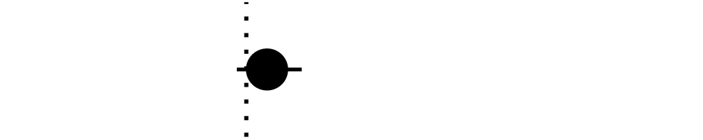

versicolor

50

1.5 (1.3, 1.8)

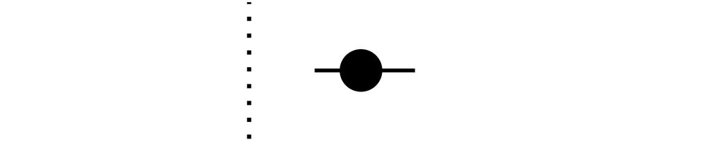

virginica

50

2.1 (1.8, 2.4)

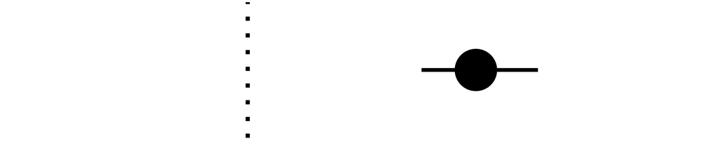

NA

NA

NA

NA (NA, NA)

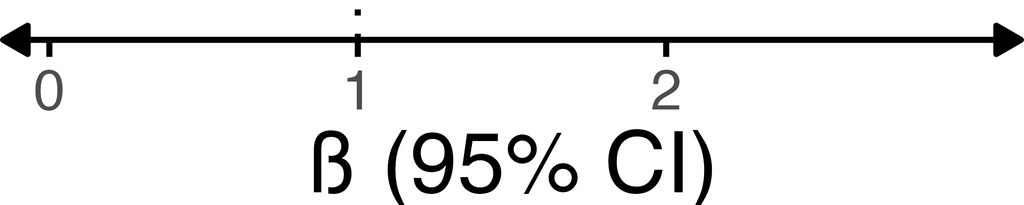

# August 1, 2022

| Projects | Status | Product | Effort |
| --- | --- | --- | --- |
| MS and CV Mortality | Team = Amit Shah (*Emory*) Draft to co-authors **8/1** | Manuscript - 1st Author, High Impact | 20% |
| F32/T32/K23 | Aim 1 = Human vagolysis and SCD **Aim 2 = Murine model of vagal withdrawal and arrhythmia** Active research into model development **daily** | *Funding* | 20% |
| EP Lab | Confirm one day in EP lab | *EP Fellowship* | 20% |
| AF Registry | Decide on retrospective/prospective cohort definitions **TBD** | *TBD* | 10% |
| UIC Clinic | Weekly clinic with Dr. Ziccardi | NA | 10% |
| Endocarditis and Pixel Density | Team = Lee Frazin, Satish Mishra, David Polman Revise still images to create standard for processing and SOP **8/3** | Pilot Study | 10% |
| PERT | Plan for IM Conference and Survey **8/5** | Manuscript - Medical Education | 5% |
| Signal Processing | CARTO into OpenEP **8/2** | Software Publication | 5% |
| Modeling Software | Forest plots by subgroups in {R}, **complete** Revise multiple modeling approach in formulas | Software Publication x 2-3 | 1% |
| Studying | General cardiology/echo boards in **Fall 2023 | Board Certification | 1% |
| Endocarditis and Arrhythmias | Meet with Atreya Mishra to complete outline **8/2** | Manuscript - Review Paper | 1% |
| HRV and CAD | Emory Biobank continually recruiting Meet with staff to assess data quality **TBD** | *Paper* | 1% |

## AF Registry

Consider additional variables:

- Recurrent events and adjudication (HF, cardiac admission, MACE)
- Holter/ECG data and repeat collection (P-wave morphology, Wilson’s vector gradient, amplitude of AF waves “coarseness”)

Will check with the MESA and ARIC data base on how repeat events were defined.

## Murine EP Studies

[figure not shown]

## Human EP Studies

[figure not shown]

# August 8, 2022

| Projects | Status | Product | Effort |
| --- | --- | --- | --- |
| EP Lab | EP lab on **8/8, 8/10, 8/11** | *EP Fellowship* | 30% |
| F32/T32/K23 | Aim 1 = Human vagolysis and SCD **Aim 2 = Murine model of vagal withdrawal and arrhythmia** Active research into model development **daily** | *Funding* | 20% |
| AF Registry | Complete AF registry for catheter ablation data dictionary **8/2** | *TBD* | 20% |
| MS and CV Mortality | Team = Amit Shah (*Emory*) Draft to co-authors **8/9** | Manuscript - 1st Author, High Impact | 10% |
| UIC Clinic | Weekly clinic with Dr. Ziccardi | NA | 10% |
| Endocarditis and Pixel Density | Team = Lee Frazin, Satish Mishra, David Polman Revise still images to create standard for processing and SOP **8/11** | Pilot Study | 10% |
| PERT | Plan for IM Conference and Survey **8/10** | Manuscript - Medical Education | 5% |
| Signal Processing | CARTO into OpenEP **8/9** | Software Publication | 5% |
| Modeling Software | Forest plots by subgroups in {R}, **complete** Revise multiple modeling approach in formulas | Software Publication x 2-3 | 1% |
| Studying | General cardiology/echo boards in **Fall 2023** ITE **10/18** | Board Certification | 1% |
| Endocarditis and Arrhythmias | Meet with Atreya Mishra to complete outline **8/12** | Manuscript - Review Paper | 1% |
| HRV and CAD | Emory Biobank continually recruiting Meet with staff to assess data quality **TBD** | *Paper* | 1% |

# August 15, 2022

| Projects | Status | Product | Effort |
| --- | --- | --- | --- |
| AF Registry | AF registry needs revamp | *TBD* | 30% |
| EP Lab | EP lab scheduled TBD | *EP Fellowship* | 20% |
| MS and CV Mortality | Team = Amit Shah (*Emory*) Draft to co-authors **8/16** | Manuscript - 1st Author, High Impact | 20% |
| F32/T32/K23 | Aim 1 = Human vagolysis and SCD **Aim 2 = Murine model of vagal withdrawal and arrhythmia** Active research into model development **daily** | *Funding* | 10% |
| UIC Clinic | Weekly clinic with Dr. Ziccardi | NA | 10% |
| Endocarditis and Pixel Density | Team = Lee Frazin, Satish Mishra, David Polman Images collected for 3/10 patients, finish patients **8/16** | Pilot Study | 10% |
| PERT | Plan for IM Conference and Survey **8/18** | Manuscript - Medical Education | 5% |
| Signal Processing | LSPro and CARTO into Matlab, **8/19** | Software Publication | 5% |
| Modeling Software | On hold | Software Publication x 2-3 | 1% |
| Studying | General cardiology/echo boards in **Fall 2023** ITE **10/18** | Board Certification | 1% |
| Endocarditis and Arrhythmias | Meet with Atreya Mishra to complete outline **8/18** | Manuscript - Review Paper | 1% |
| HRV and CAD | Emory Biobank continually recruiting Meet with staff to assess data quality **TBD** | *Paper* | 1% |

**Next Steps**

1. Generate list of MRN for data collection
2. Use new REDCap to obtain ECG/ablation data
3. Run preliminary analysis on first 100 patients
4. Consider expansion to JBVA/ACMC data

# August 22, 2022

| Projects | Status | Product | Effort |
| --- | --- | --- | --- |
| F32/T32/K23 | Aim 1 = Human vagolysis and SCD **Aim 2 = Murine model of vagal withdrawal and arrhythmia** Active research into model development **daily** | *Funding* | 50% |
| AF Registry | Team = Shaurya, Hatem, Malek, Complete review 200 charts to add ablation data **8/26** Complete 50 of 100 current UIC ablation patients in REDCap **8/26** Provide SOP for data collection **8/22** | *TBD* | 30% |
| Endocarditis and Pixel Density | Team = Lee Frazin, Satish Mishra, David Polman Images collected for 3/10 patients, finish patients **8/26** | Pilot Study | 20% |
| EP Lab | EP lab scheduled TBD | *EP Fellowship* | 10% |
| MS and CV Mortality | Team = Amit Shah (*Emory*) Final draft for co-authors **8/22** | Manuscript - 1st Author, High Impact | 10% |
| UIC Clinic | Weekly clinic with Dr. Ziccardi | NA | 10% |
| PERT | Plan for IM Conference and Survey **8/24** | Manuscript - Medical Education | 10% |
| Signal Processing | LSPro and CARTO into Matlab **success** | Software Publication | 5% |
| Studying | General cardiology/echo boards in **Fall 2023** ITE **10/18** | Board Certification | 5% |
| Modeling Software | On hold | Software Publication x 2-3 | 1% |
| Endocarditis and Arrhythmias | Meet with Atreya **TBD** | Manuscript - Review Paper | 1% |
| HRV and CAD | Emory Biobank continually recruiting Meet with staff to assess data quality **TBD** | *Paper* | 1% |

## AF Registry

**Status**

- REDCap is in progress
- Have an additional list of registry patients that may/may not have had ablation

**Next Steps**

1. Complete 100 REDCap patients
2. Identify 300 patients that have potentially had ablation

## CARTO Maps

- Ablation quantification
- Activation mapping
- EGM annotation
- Voltage mapping
- Conduction velocity
- Earliest/latest activation
- Geometry data

# September 12, 2022

## AF Registry

REDCap data dictionary is finalized. Next steps are:

1. Data entry for outcomes
2. Finalization of new patients to add from AF ablation registry

## Genetics

Currently able to:

- Format large SNP data sets into appropriate tables
- Utilize `PLINK` and `MERLIN` to process Chen’s genetics data
- Run from R to help analyze findings

Next steps:

- Confirm ancestry (for practice) percent likelihood
- Then, once outcome data is complete, analyze differences by race

Analytical methods:

- Time to binary outcome of recurrence
- Recurrent event analysis for AF recurrence
- Can revise with Bayesian modeling in `STAN` as well

Stress Epidemiology, Arrhythmia Mechanisms, Clinical, Computational